# Homework 6

### Current Price

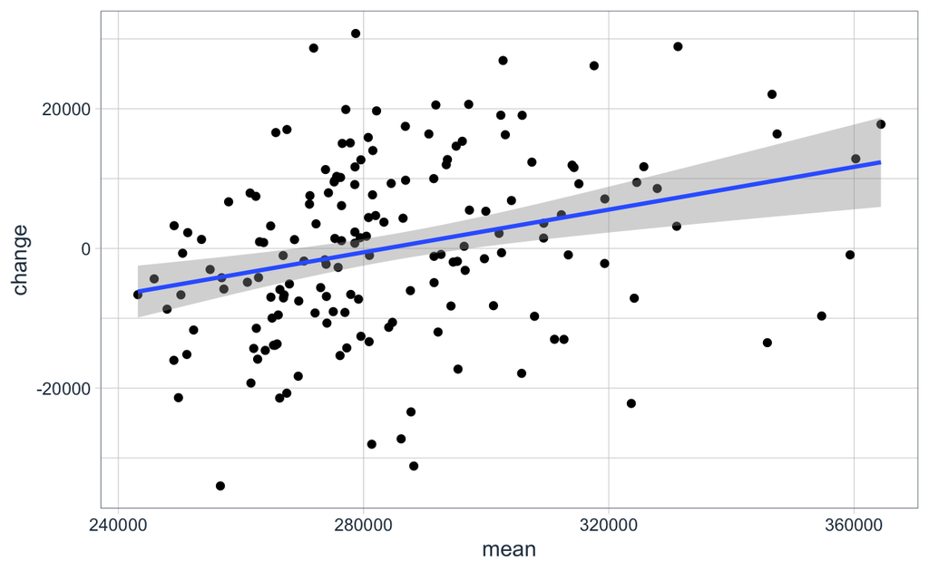

```r
connecticut %>%
  group_by(month = floor_date(sale_date, "month")) %>%
  summarise(mean = mean(sale_price)) %>%
  mutate(previous = lag(mean),
         change = (mean - previous),
         percent_change = (change/mean) * 100) %>%
  ggplot(aes(x = mean, y = change)) +
  geom_point() +
  geom_smooth(method = "lm") +
  theme_tq()
```

### Seasonality

```r
c <- connecticut %>%
  group_by(month = floor_date(sale_date,
                              "month"),
           year = floor_date(sale_date,
                            "year")) %>%
  filter(property_type == "Single Family") %>%
  summarize(mean = mean(sale_price)) %>%
  mutate(Month2 = tsibble::yearmonth(month)) %>%
  ungroup(month)

  c <- select(c,
         "Month2",
         "mean")
  c <- as_tsibble(c)

  gg_season(c)
```

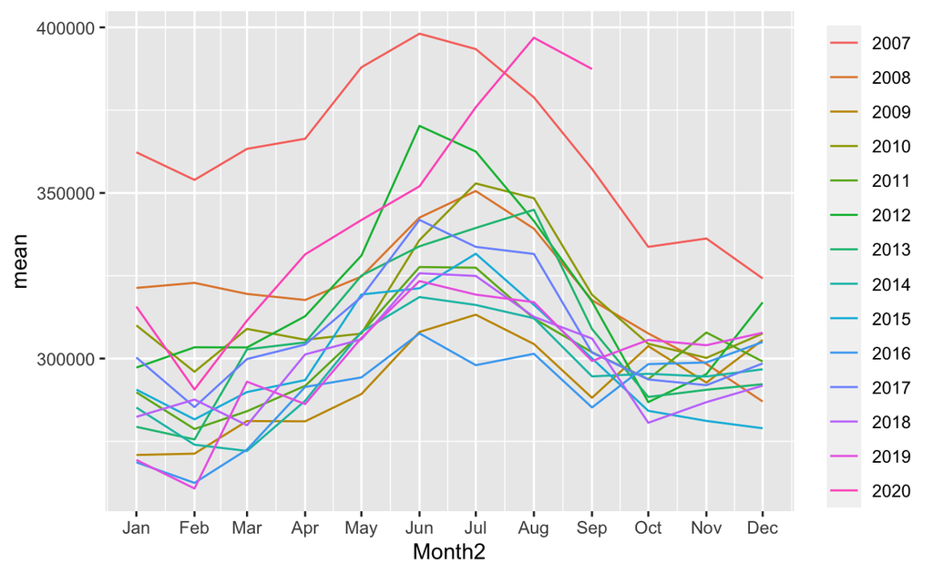

### Population

```r
# census_api_key("a2e56978408ace3c130f93ace8eb74b48564a9f4", install = TRUE)
# readRenviron("~/.Renviron")
# Sys.getenv("CENSUS_API_KEY")
get_estimates(geography = "county",
              product = "population",
              state = "CT",
              time_series = TRUE,
              year = 2019)
```

```
# A tibble: 192 × 5
   NAME                           DATE GEOID variable  value
   <chr>                         <dbl> <chr> <chr>     <dbl>
 1 New Haven County, Connecticut     1 09009 POP      862477
 2 New Haven County, Connecticut     2 09009 POP      862442
 3 New Haven County, Connecticut     3 09009 POP      863357
 4 New Haven County, Connecticut     4 09009 POP      863871
 5 New Haven County, Connecticut     5 09009 POP      864566
 6 New Haven County, Connecticut     6 09009 POP      862820
 7 New Haven County, Connecticut     7 09009 POP      862885
 8 New Haven County, Connecticut     8 09009 POP      860186
 9 New Haven County, Connecticut     9 09009 POP      857901
10 New Haven County, Connecticut    10 09009 POP      857748
# … with 182 more rows
```

## Litchfield County

### Delta mean

**Create graphic of mean yearly sale price for just Litchfield County, group by property type**

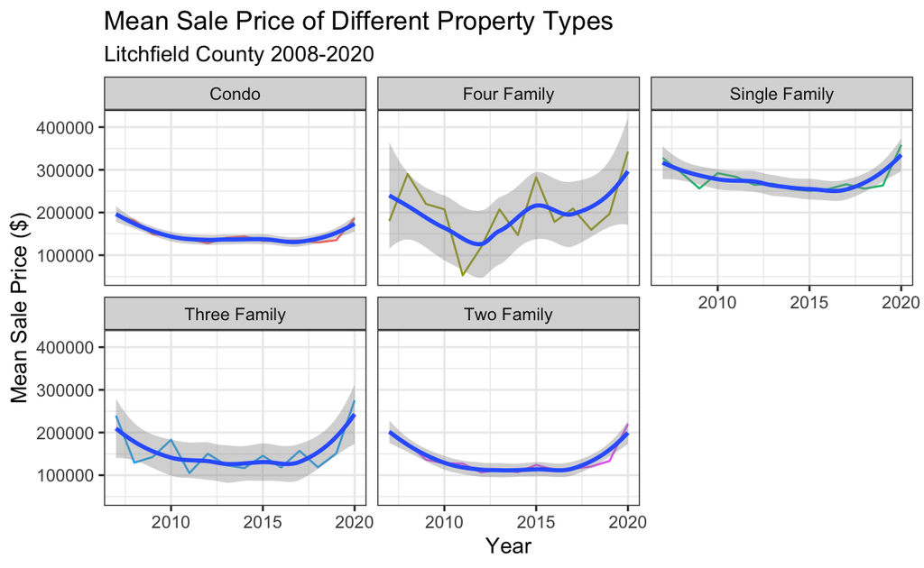

```r
connecticut %>%
  filter(county == "litchfield") %>%
  group_by(property_type,
           year = lubridate::floor_date(sale_date, "year")) %>%
  summarize(mean_litchfield = mean(sale_price)) %>%
  ggplot(aes(x = year,
             y = mean_litchfield)) +
  geom_line(aes(color = property_type)) +
  geom_smooth() +
  theme_bw() +
  labs(title = "Mean Sale Price of Different Property Types",
       subtitle = "Litchfield County 2008-2020",
       x = "Year",
       y = "Mean Sale Price ($)") +
  facet_wrap(vars(property_type)) +
  guides(color = "none")
```

- Insights:
  - Similar to the statewide data it appears that multi unit properties (i.e., Four-Family, Three Family, etc.) are increasing at a faster rate than “Single Family” properties.
  - “Four Family” properties appear to be the most volatile.
  - We have to keep in mind what we observed earlier about our sample size with regards to multi unit properties, they constitute our smallest sample.

Next we examine the counts of property types in Litchfield County.

### Counts

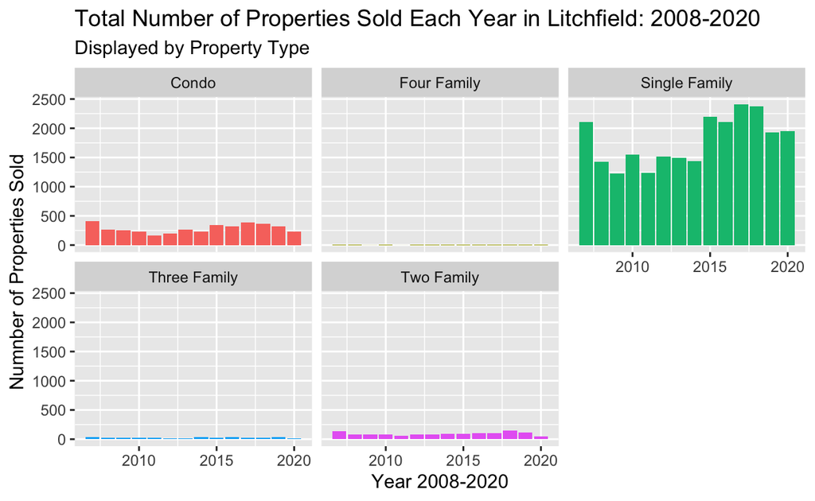

```r
Litchfield <- connecticut %>%
  group_by(sale_year) %>%
  filter(county == "litchfield")

Litchfield %>%
  group_by(sale_year, property_type) %>%
  ggplot(aes(x = sale_year, fill = property_type)) +
  geom_bar(aes(stat="identity")) +
  facet_wrap(vars(property_type)) +
  labs(title = "Total Number of Properties Sold Each Year in Litchfield: 2008-2020",
       subtitle = "Displayed by Property Type",
       x = "Year 2008-2020",
       y = "Numnber of Properties Sold") +
  theme(legend.position = "none")
```

Here we can see clearly that our data set is primarily made up of “Single Family” properties and “Condos”.

**Examine counts of property type in Litchfield County**

```r
Litchfield %>%
  group_by(property_type) %>%
  count(property_type) %>%
  rename("Property Type" = "property_type",
         "Properties Sold" = "n") %>%
  knitr::kable(caption = "Counts of Property Types Sold: Litchfield County") %>%
  kable_classic(full_width = T) %>%
  row_spec(2, background = "yellow") %>%
  row_spec(4, background = "yellow")
```

Table 1: Counts of Property Types Sold: Litchfield County

| Property Type | Properties Sold |
| --- | --- |
| Condo | 4005 |
| Four Family | 64 |
| Single Family | 24969 |
| Three Family | 363 |
| Two Family | 1305 |

Here we can see a partial explanation for the volatility of the mean sale price of “Four Family” properties; with only 64 observations over 14 years it seems hard to rely on the data. We also see that “Three Family” is not well represented over the time period.

**Looking a little deeper at “Four” and “Three Family” properties**

```r
Litchfield %>%
  filter(property_type == "Four Family" | property_type == "Three Family") %>%
  group_by(sale_year) %>%
  count(property_type)  %>%
  pivot_wider(names_from = property_type, values_from = n) %>%
  rename("Sale Year" = "sale_year") %>%
  kable(align = c("l", "c", "r"),
               caption = "Counts of Four Family Properties Sold Each Year: Litchfield County") %>%
  kable_classic(full_width = T) %>%
  column_spec(1, bold = T) %>%
  row_spec(0, bold = T) %>%
  row_spec(5:7, background = "yellow") %>%
  row_spec(14, background =  "yellow")
```

Table 2: Counts of Four Family Properties Sold Each Year: Litchfield County

| Sale Year | Four Family | Three Family |
| --- | --- | --- |
| 2007 | 3 | 40 |
| 2008 | 3 | 21 |
| 2009 | 2 | 28 |
| 2010 | 4 | 25 |
| 2011 | 1 | 21 |
| 2012 | 3 | 18 |
| 2013 | 3 | 16 |
| 2014 | 5 | 31 |
| 2015 | 3 | 29 |
| 2016 | 5 | 31 |
| 2017 | 4 | 23 |
| 2018 | 10 | 30 |
| 2019 | 10 | 40 |
| 2020 | 8 | 10 |

Here I finally got use the pivot function, I didn’t notice any opportunities before this.

I have highlighted 2011-2013 and 2020 where there are very limited observations for “Three” and “Four Family” properties. While the counts do increase in some of the years the data does not appear reliable at even the county level. As a result of the limitations of the data examining different “property types” beyond the county level will not be revealing or possible.

As we examine the towns in Litchfield County, we will only be looking a “Single Family” properties.

### Towns: Litchfield County

**Filter Litchfield County Object for only “Single Family” properties**

```r
Litchfield_SF <- Litchfield %>%
  filter(property_type == "Single Family")
```

As a result of the data being limited for “property types” other than “Single Family” I will filter for “Single Family” before I look at the specific towns in Litchfield County.

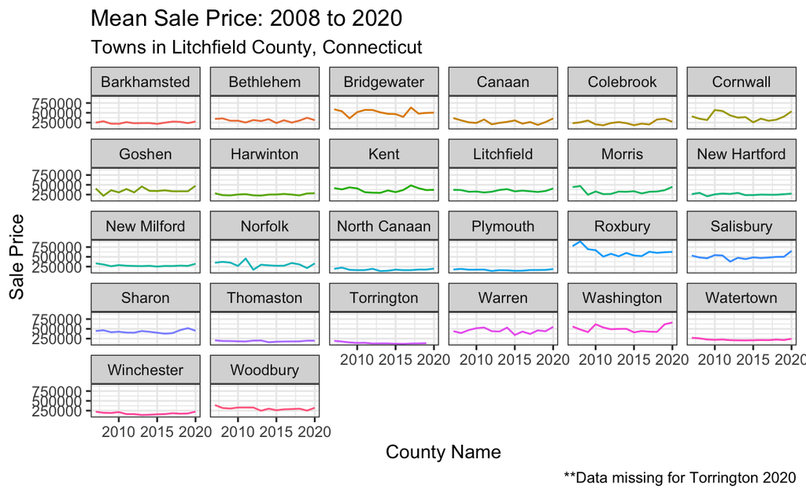

```r
Litchfield %>%
  group_by(town, year = lubridate::floor_date(sale_date, "year")) %>%
  summarize(meanL = mean(sale_price)) %>%
  ggplot(aes(x = year, y = meanL)) +
  geom_line(aes(color = town)) +
  labs(title = "Mean Sale Price: 2008 to 2020",
       subtitle = "Towns in Litchfield County, Connecticut",
       x = "County Name",
       y = "Sale Price",
       caption = "**Data missing for Torrington 2020") +
  theme_bw() +
  facet_wrap(vars(town)) +
  guides(color = "none")
```

**Create object to analyze the delta mean sale price of Litchfield County towns**

```r
L08 <- Litchfield_SF %>%
  group_by(town, sale_year) %>%
  summarise(mean_L08 = mean(sale_price)) %>%
  filter(sale_year == "2008")

L20 <- Litchfield_SF %>%
  group_by(town, sale_year) %>%
  summarise(mean_L20 = mean(sale_price)) %>%
  filter(sale_year == "2020")

L_combined <- L08 %>%
  left_join(L20, by = "town")

L_combined <- L_combined %>%
  mutate(L_delta_mean = mean_L20 - mean_L08) %>%
  mutate(L_c_mean = (mean_L20 - mean_L08)/mean_L08) %>%
  mutate(L_c_mean = L_c_mean * 100) %>%
  mutate(across(contains("mean"), round, 2))
```

**Create bargraph of the delta mean of Litchfield County towns**

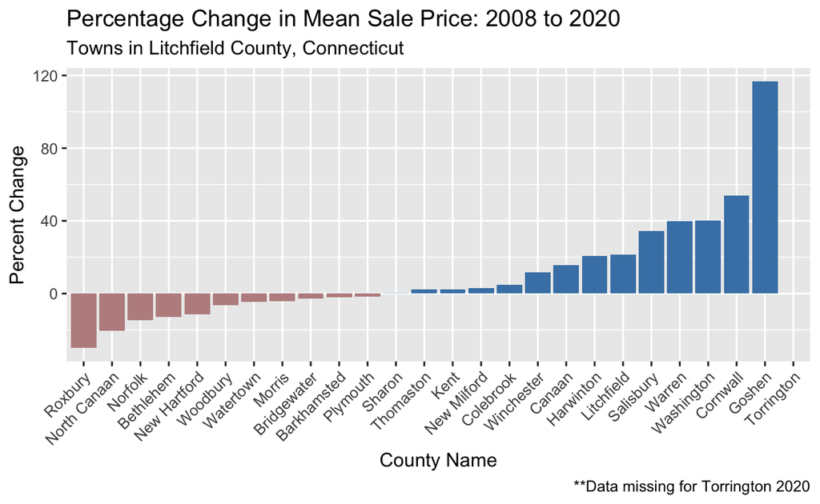

```r
L_combined %>%
  mutate(Color = ifelse(L_c_mean < 0, "rosybrown","steelblue")) %>%
  ggplot(aes(x = reorder(town, +L_c_mean),
             y = L_c_mean,
             fill = Color)) +
  geom_col() +
  labs(title = "Percentage Change in Mean Sale Price: 2008 to 2020",
       subtitle = "Towns in Litchfield County, Connecticut",
       x = "County Name",
       y = "Percent Change",
       caption = "**Data missing for Torrington 2020") +
  theme(axis.text.x = element_text(angle = 45,
                                            hjust = 1)) +
  scale_fill_identity(guide = "none")
```

This graphic displays the change in mean sale price in all the Litchfeild County towns from 2008 to 2020.

- Some interesting takeaways:
  - Torrington has no data for a change in mean indicating that either 2008 or 2020 are missing.
  - Goshen and Cornwall show a 116.77% and 54.03%. respectively, increases of this magnitude seem potentially implausble.
  - These items will be investigated further.
- Other takeaways:
  - While the aggregated data show that Litchfield property values have increased the most, this is not true for all of Litchfield.
  - By town, it appears that approximately half of Litchfield is increasing and the other half is not.
  - We could hypothesize that as a result of the pandemic people wanted to move away from densely populated areas and as a result Litchfield County became more desirable. We could further postulate that the towns that have not seen an increase in mean sale price could be lagging behind and may in the future.
  - We could also speculate that the higher property values in Fairfield County have caused people to look elsewhere to buy properties.
  - This is all highly speculative and without further analysis and/or information nothing definitively actionable can be ascertained.

**Change in mean Torrington**

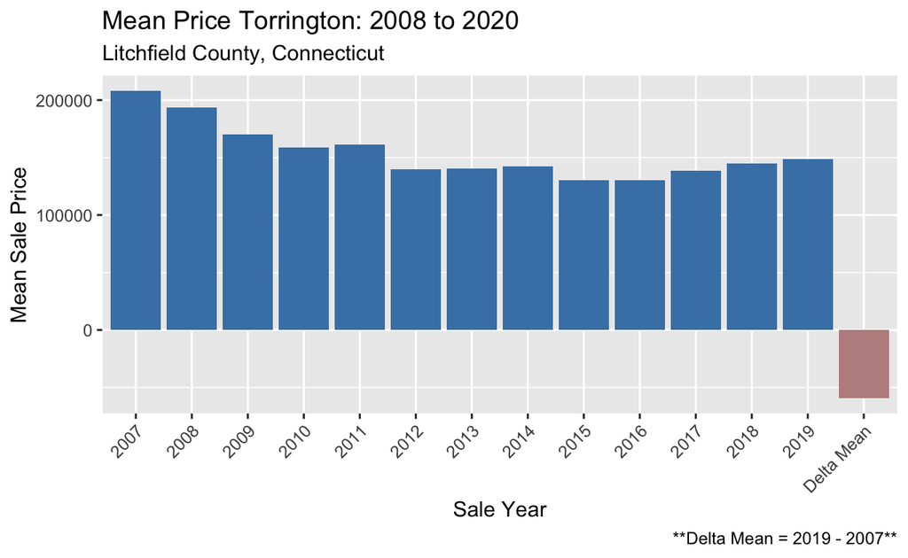

```r
Litchfield_SF %>%
  filter(town == "Torrington") %>%
  select(sale_year, sale_price) %>%
  group_by(sale_year) %>%
  summarise(mean = mean(sale_price)) %>%
  pivot_wider(names_from = sale_year, values_from = mean) %>%
  mutate("Delta Mean" = (`2019`-`2007`)) %>%
  pivot_longer(0:14, names_to = "Sale_Year", values_to = "Mean_Sale_Price") %>%
  mutate(Color = ifelse(Mean_Sale_Price < 0, "rosybrown","steelblue")) %>%
  ggplot(aes(x = Sale_Year, y = Mean_Sale_Price, fill = Color)) +
  geom_col() +
  theme(axis.text.x = element_text(angle = 45,
                                            hjust = 1)) +
  scale_fill_identity(guide = "none") +
  labs(title = "Mean Price Torrington: 2008 to 2020",
       subtitle = "Litchfield County, Connecticut",
       x = "Sale Year",
       y = "Mean Sale Price",
       caption = "**Delta Mean = 2019 - 2007**")
```

Now we will take a look Goshen. A hundred percent increase in mean sale price is a little remarkable. We will analyze to see if there is an explanation in the data.

```r
Litchfield_SF %>%
  filter(town == "Goshen") %>%
  group_by(sale_year) %>%
  summarize(goshen_mean = mean(sale_price),
            properties_sold = count(sale_year))
```

```
# A tibble: 14 × 3
   sale_year goshen_mean properties_sold
       <dbl>       <dbl>           <int>
 1      2007     405302.              45
 2      2008     219587.               9
 3      2009     360256.              45
 4      2010     303607               50
 5      2011     391851.              58
 6      2012     305958.              24
 7      2013     456833.              15
 8      2014     350857.              56
 9      2015     340886.              71
10      2016     361325.              75
11      2017     333381.              52
12      2018     333617.              12
13      2019     337689.              80
14      2020     475989.              64
```

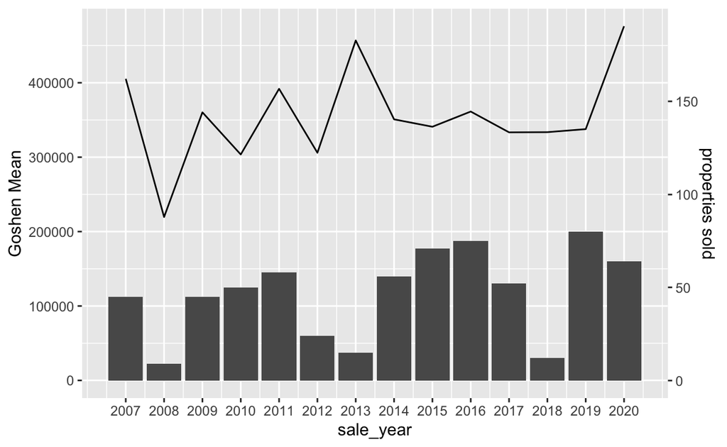

```r
  Litchfield_SF %>%
  filter(town == "Goshen") %>%
  group_by(sale_year) %>%
  summarize(goshen_mean = mean(sale_price),
            properties_sold = count(sale_year)) %>%
  ggplot(aes(x = sale_year)) +
  geom_line(aes(x = sale_year, y = goshen_mean)) +
  geom_col(aes(x = sale_year, y = properties_sold*2500)) +
  scale_x_continuous(breaks = seq(2007, 2020, 1)) +
  scale_y_continuous(name = "Goshen Mean", sec.axis = sec_axis(~./2500, name = "properties sold"))
```

## Where I will go from here

**What is missing from your final project?**

I think my project is still kind of unorganized. I need to move some things to the appendix, remove others, and move some things around. I also need to clean up and recode some of the graphics. I also need to write out explanations of the decisions I made and the graphics. Generally, I need to work on the narration of the project. I also missing error bars.

**What do I hope to accomplish**

I hope to accomplish everything above and continue the analysis for Fairfield County. I also to refine and/or polish the graphics and tables.

```r
#ts_object <- connecticut %>%
  #filter(property_type == "Single Family") %>%
  #group_by(month = lubridate::floor_date(sale_date, "month")) %>%
  #summarise(mean = mean(sale_price))
#ts_object_2 <- xts(ts_object$mean, ts_object$month)
```